# Combining fish and benthic communities into multiple regimes reveals complex reef dynamics

#### *Analysis by Mary K. Donovan*

Contact: marykdonovan@gmail.com

Supplementary material for:  
*Donovan MK, Friedlander AM, Lecky J, Jouffray JB, Williams GJ, Wedding LM, Crowder LB, Erickson A, Graham NAJ, Gove JM, Kappel CV, Karr K, Kittinger JN, Norström AV, Nyström M, Oleson KL, Stamoulis KA, White C, Williams ID, Selkoe KA. Combining fish and benthic communities into multiple regimes reveals complex reef dynamics. Scientific Reports*

## Initialization

The data is hosted in an online repository at http://datadryad.org, and the data can be accessed with the rdryad package or by visiting the website

```r
data <- read.csv(file.path(getwd(),'data','Hawaii_regimes.csv'))
# data <- download_url("xxx")

data_time <- read.csv(file.path(getwd(),'data','Hawaii_regime_timeseries_wcoords.csv'))
# data_time <- download_url("xxx")

drivers <- read.csv(file.path(getwd(),'data','Hawaii_regime_drivers.csv'))
# drivers <- download_url("xxx")

library(mclust) # v5.3
library(plyr) # v1.8.4
library(vegan) # v5.3
library(reshape2) # v1.4.2
library(plotrix) # v3.6.6
library(Hmisc) # v4.0.3
library(rjags) # v4.6
library(wesanderson) # v0.3.6.9000
library(parallel) # v3.4.1
```

## Data transformation

Scale each variable to range from 0 to 1:

```r
myscale <- function(x) {(x - min(x, na.rm=TRUE))/(max(x,na.rm=TRUE) -
                                                 min(x, na.rm=TRUE))}
data.r <- as.data.frame(lapply(data[c('Coral','Macro','Other','Turf','CCA','Browsers','Grazers','Scrapers','Predators','SecConsumers')], myscale))
```

Fourth-root transform each variable:

```r
data.r <- sqrt(sqrt(data.r))
```

## Model based clustering

Use model-based clustering with the `mclust` package to identify regimes.

The first step is to fit clusters for multiple model types, and select the best model using model selection and the number of clusters approximated with Bayes factors and Bayesian Information Criterion:

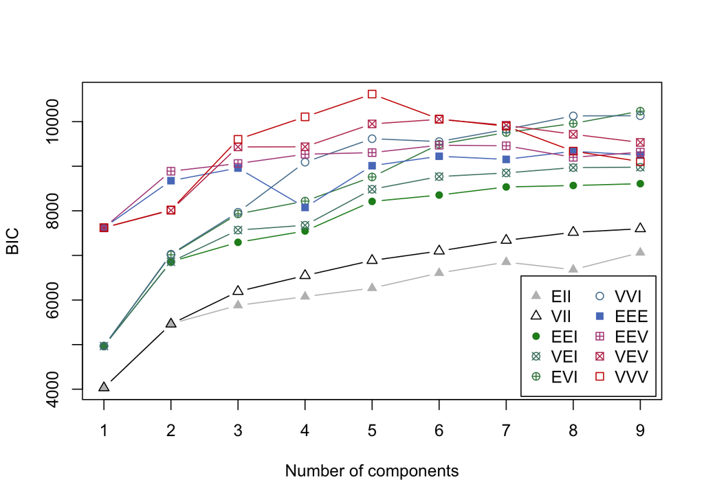

```r
regmod <- mclustBIC(data.r,prior=priorControl())
plot(regmod)
```

```r
summary(regmod, data=data.r)
```

```
## Best BIC values:
##             VVV,5      EVI,9      VVI,9
## BIC      10617.21 10234.1082 10132.0568
## BIC diff     0.00  -383.0988  -485.1503
##
## Classification table for model (VVV,5):
##   1   2   3   4   5
## 158 205 250 214 200
```

Based on this this plot, find the optimal number of clusters and the model type, based on the maximum BIC, and use this to plug into the final model fit.

```r
regmod_final <- Mclust(data.r,prior=priorControl(),G=5,modelNames=c("VVV"))
summary(regmod_final,parameters=F)
```

```
## ----------------------------------------------------
## Gaussian finite mixture model fitted by EM algorithm
## ----------------------------------------------------
##
## Mclust VVV (ellipsoidal, varying volume, shape, and orientation) model with 5 components:
##
## Prior: defaultPrior()
##
##  log.likelihood    n  df      BIC     ICL
##        6449.312 1027 329 10617.21 10476.2
##
## Clustering table:
##   1   2   3   4   5
## 158 205 250 214 200
```

## Plot in multivariate space

Plot in multidimensional space using `metaMDS` function in `vegan` package to visualize regimes:

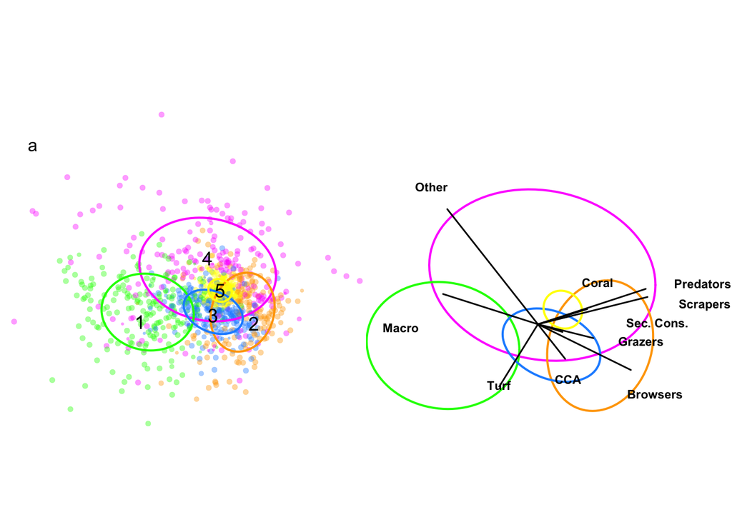

```r
# create a dataframe that stores the results
temp <- cbind(data.r, "clust"= regmod_final$classification,"uncert"=regmod_final$uncertainty)
clustgrp <- data.frame("clust"=c(1,2,3,4,5),"regime"=c(2,3,1,5,4)) #renumber the regimes
temp <- join(temp, clustgrp,by='clust')
temp$uncert_1 <- 1-temp$uncert # transform uncertainty

# vegan mds fuction
mds_x <- suppressMessages(metaMDS(data.r,autotransform=F,k=2,trymax=5,trace=0))
# actual run was with trymax=50, setting to lower number for faster rendering of rmarkdown

# set up colors for plot
colvec <- c("orange","green","dodgerblue","yellow","magenta")
ct <- 100
colvec_trans <- c(rgb(255,165,0,ct,max=255),rgb(0,255,0,ct,max=255),rgb(30,144,255,ct,max=255),rgb(255,255,0,ct,max=255),rgb(255,0,255,ct,max=255))

# plot
par(mfrow=c(1,2),mar=c(0,0,0,0))
plot(mds_x,type="n",xlim=c(-1,.77),ylim=c(-.6,1),xaxt="n",yaxt="n",xlab="",ylab="",bty="n")
points(mds_x,display="sites",cex=(temp$uncert_1^1.2)*0.7,col=colvec[temp$clust],bg=colvec_trans[temp$clust],pch=21,lwd=0.1)
for(i in c(5,2,1,3,4)) ordiellipse(mds_x, groups=temp$clust, show.groups=i, col=colvec[i],lwd=2, conf=.50)
text(-.9,.8,"a",cex=1)
text(0.19655553+.06,-0.06758782-0.06,"2",cex=1.1,font=1)
text(-0.29963102-.04,-0.06718082-.05,"1",cex=1.1,font=1)
text(0.04289366,-0.06607040-0.02,"3",cex=1.1,font=1)
text(0.07874599,0.04615998,"5",cex=1.1,font=1)
text(0.01396763,0.15545153+0.06,"4",cex=1.1,font=1)

plot(mds_x,type="n",xlim=c(-.5,.57),ylim=c(-.5,.9),xaxt="n",yaxt="n",xlab="",ylab="",bty="n")
for(i in c(5,2,1,3,4)) ordiellipse(mds_x, groups=temp$clust, show.groups=i, col=colvec[i],lwd=2, conf=.50)
reg.arrow <- scores(mds_x,choices=1:3,display="sp",scaling=2)
arrows(0,0,reg.arrow[,1],reg.arrow[,2],length=0,lty=1,cex=3,lwd=1.5,col="black")
colnames(temp)[c(7:11)] <- c("Browsers","Grazers","Scrapers","Predators","SC")
text(0.15822316+0.03 ,0.08145200+.05,"Coral",font=2,cex=0.7)
text(-0.30281789-0.13,-0.01094597,"Macro",font=2,cex=0.7)
text(-0.28636879-.05,0.36413499+.07,"Other",font=2,cex=0.7)
text(-0.12292336,-0.16294542-0.03,"Turf",font=2,cex=0.7)
text(0.08508690+0.01,-0.13404772-0.04,"CCA",font=2,cex=0.7)
text(0.29004490+0.08, -0.20112700-0.02,"Browsers",font=2,cex=0.7)
text(0.17544408+0.15,-0.04426472-0.01,"Grazers",font=2,cex=0.7)
text(0.34681479+0.18 ,0.06135945,"Scrapers",font=2,cex=0.7)
text(0.34032304+0.18,0.10817131+0.02,"Predators",font=2,cex=0.7)
text(0.07699135+0.3,-0.02065685+0.025,"Sec. Cons.",font=2,cex=0.7)
text(-.6,.735,"b",cex=1)
```

## Multivariate dispersion

Calculate multivariate dispersion to test multivariate homogeneity of group dispersion:

```r
bd <- betadisper(dist(data.r),temp$regime)
bd
```

```
##
##  Homogeneity of multivariate dispersions
##
## Call: betadisper(d = dist(data.r), group = temp$regime)
##
## No. of Positive Eigenvalues: 10
## No. of Negative Eigenvalues: 0
##
## Average distance to median:
##      1      2      3      4      5
## 0.4820 0.4611 0.4963 0.7222 0.3037
##
## Eigenvalues for PCoA axes:
##    PCoA1    PCoA2    PCoA3    PCoA4    PCoA5    PCoA6    PCoA7    PCoA8
## 129.7885  68.4372  60.9563  40.3199  30.7775  23.6597  17.3733  16.2586
```

```r
permutest(bd,pairwise=T)
```

```
##
## Permutation test for homogeneity of multivariate dispersions
## Permutation: free
## Number of permutations: 999
##
## Response: Distances
##             Df Sum Sq Mean Sq      F N.Perm Pr(>F)
## Groups       4 18.369  4.5923 215.95    999  0.001 ***
## Residuals 1022 21.733  0.0213
## ---
## Signif. codes:  0 '***' 0.001 '**' 0.01 '*' 0.05 '.' 0.1 ' ' 1
##
## Pairwise comparisons:
## (Observed p-value below diagonal, permuted p-value above diagonal)
##             1           2           3           4     5
## 1              1.5900e-01  2.8800e-01  1.0000e-03 0.001
## 2  1.5120e-01              2.4000e-02  1.0000e-03 0.001
## 3  2.8086e-01  2.6866e-02              1.0000e-03 0.001
## 4  1.2950e-42  1.5002e-34  6.8779e-33             0.001
## 5  1.6669e-50  8.3059e-32  4.0722e-49 1.4196e-100
```

## Sensitivity to depth

Repeat above analysis for multiple depth bins and compare results:

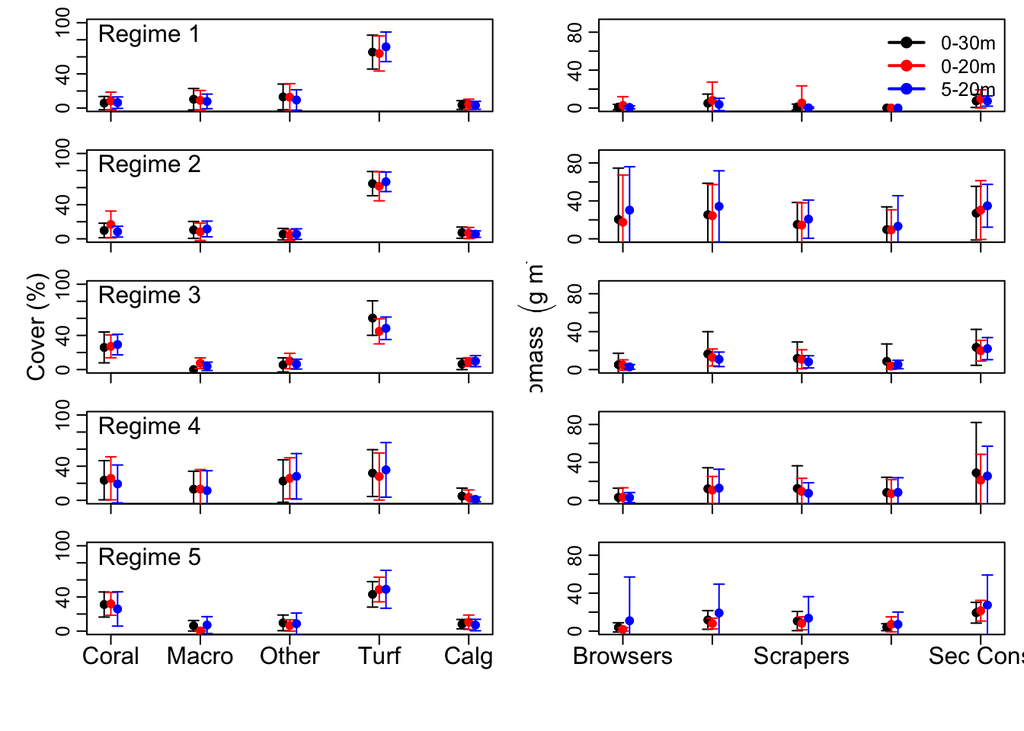

```r
# less than 20m
depth.sub.l20 <- data[data$Depth_m <=20 | is.na(data$Depth_m),] # subset data
data.120.r <- as.data.frame(lapply(depth.sub.l20[c('Coral','Macro','Other','Turf','CCA','Browsers','Grazers','Scrapers','Predators','SecConsumers')], myscale)) # scale
data.120.r <- sqrt(sqrt(data.120.r)) # transform
regmod_l20 <- Mclust(data.120.r,prior=priorControl(),G=5,modelNames=c("VVV")) # cluster

temp <- cbind(data[data$Depth_m <=20 | is.na(data$Depth_m),], 'clust'=regmod_l20$classification) # save results for plot
clustgrp.l20 <- data.frame('clust'=c(1,2,3,4,5),'regime'=c(1,3,2,5,4)) # match with regime numbers
temp <- join(temp[c('Coral','Macro','Other','Turf','CCA','Browsers','Grazers','Scrapers','Predators','SecConsumers','clust')], clustgrp.l20, by='clust'); temp$id <- seq(1:nrow(temp))
reg.l20.result <- melt(temp, id=c('id','clust','regime'))
reg.l20.result <- ddply(reg.l20.result,.(regime,variable),summarise,'mean'=mean(value),'sd'=sd(value),'n'=length(variable))
rl20.mean <- dcast(reg.l20.result, regime~variable,value.var='mean')
rl20.sd <- dcast(reg.l20.result, regime~variable,value.var='sd')

# 5m to 20m
depth.sub.5_20 <- data[data$Depth_m <=20 & data$Depth_m >= 5 | is.na(data$Depth_m),]
data.5_20.r <- as.data.frame(lapply(depth.sub.5_20[c('Coral','Macro','Other','Turf','CCA','Browsers','Grazers','Scrapers','Predators','SecConsumers')], myscale)) # scale
data.5_20.r <- sqrt(sqrt(data.5_20.r)) # transform
regmod_5_20 <- Mclust(data.5_20.r,prior=priorControl(),G=5,modelNames=c("VVV")) # cluster

temp <- cbind(data[data$Depth_m <=20 & data$Depth_m >= 5 | is.na(data$Depth_m),], 'clust'=regmod_5_20$classification) # save results for plot
clustgrp.5_20 <- data.frame('clust'=c(1,2,3,4,5),'regime'=c(1,3,5,2,4)) # match with regime numbers
temp <- join(temp[c('Coral','Macro','Other','Turf','CCA','Browsers','Grazers','Scrapers','Predators','SecConsumers','clust')], clustgrp.5_20, by='clust'); temp$id <- seq(1:nrow(temp))
reg.5_20.result <- melt(temp, id=c('id','clust','regime'))
reg.5_20.result <- ddply(reg.5_20.result,.(regime,variable),summarise,'mean'=mean(value),'sd'=sd(value),'n'=length(variable))
r5_20.mean <- dcast(reg.5_20.result, regime~variable,value.var='mean')
r5_20.sd <- dcast(reg.5_20.result, regime~variable,value.var='sd')

# main result (0-30m)
temp <- cbind(data, "clust"= regmod_final$classification)
clustgrp <- data.frame("clust"=c(1,2,3,4,5),"regime"=c(3,1,2,5,4)) #renumber the regimes
temp <- join(temp[c('Coral','Macro','Other','Turf','CCA','Browsers','Grazers','Scrapers','Predators','SecConsumers','clust')], clustgrp, by='clust'); temp$id <- seq(1:nrow(temp))
reg.main.result <- melt(temp, id=c('id','clust','regime'))
reg.main.result <- ddply(reg.main.result,.(regime,variable),summarise,'mean'=mean(value),'sd'=sd(value),'n'=length(variable))
rm.mean <- dcast(reg.main.result, regime~variable,value.var='mean')
rm.sd <- dcast(reg.main.result, regime~variable,value.var='sd')
```

## Regime summary

Calculate summaries, and explore patterns of Depth, habitat, wave exposure across regimes:

```r
# main content of Table 1
ddply(data, .(regime), summarise,
      'Coral'=mean(Coral),
      'Macro'=mean(Macro),
      'Other'=mean(Other),
      'Turf'=mean(Turf),
      'CCA'=mean(CCA),
      'Browsers'=mean(Browsers),
      'Grazers'=mean(Grazers),
      'Scrapers'=mean(Scrapers),
      'Predators'=mean(Predators),
      'SecConsumers'=mean(SecConsumers),
      'Num_Sites'=length(regime),
      'Complexity'=mean(Complexity,na.rm=T),
      'Depth_m'=mean(Depth_m,na.rm=T))
```

```
##   regime     Coral     Macro     Other     Turf      CCA  Browsers
## 1      1  5.808145 10.337903 13.046782 65.56638 3.520427  1.044423
## 2      2  9.773877 10.425969  5.388199 64.66148 7.221056 20.457272
## 3      3 25.952773  0.000000  5.502929 60.34410 6.467152  5.171253
## 4      4 23.547009 13.037354 22.624460 31.91114 4.950805  3.110678
## 5      5 31.146399  6.247924  9.648163 43.03978 8.115233  3.921824
##     Grazers  Scrapers Predators SecConsumers Num_Sites Complexity
## 1  5.058558  1.140736  0.000000     7.514978       205   6.540798
## 2 25.379982 15.114670  9.743909    27.005457       250  12.119544
## 3 16.476988 11.767019  8.681527    23.435272       158  10.708496
## 4 12.187441 12.553874  8.279440    28.942220       200  10.267957
## 5 11.737973 10.604040  4.122248    19.348718       214  13.519127
##     Depth_m
## 1  8.775964
## 2 11.433956
## 3  8.250276
## 4 10.187148
## 5  9.567027
```

```r
# patterns across exposure
temp <- ddply(data,.(regime,Exposure),'nrow')
temp <- dcast(temp, regime~Exposure,value.var='nrow')
temp[2:5] <- temp[2:5]/rowSums(temp[2:5])

# patterns across depth
summary(lm(Depth_m~as.factor(regime),data=data))
```

```
##
## Call:
## lm(formula = Depth_m ~ as.factor(regime), data = data)
##
## Residuals:
##      Min       1Q   Median       3Q      Max
## -10.9340  -4.8975  -0.7331   3.3005  20.4497
##
## Coefficients:
##                    Estimate Std. Error t value Pr(>|t|)
## (Intercept)          8.7760     0.4376  20.056  < 2e-16 ***
## as.factor(regime)2   2.6580     0.5913   4.496 7.75e-06 ***
## as.factor(regime)3  -0.5257     0.6613  -0.795   0.4268
## as.factor(regime)4   1.4112     0.6212   2.272   0.0233 *
## as.factor(regime)5   0.7911     0.6100   1.297   0.1950
## ---
## Signif. codes:  0 '***' 0.001 '**' 0.01 '*' 0.05 '.' 0.1 ' ' 1
##
## Residual standard error: 6.173 on 997 degrees of freedom
##   (25 observations deleted due to missingness)
## Multiple R-squared:  0.03222,    Adjusted R-squared:  0.02833
## F-statistic: 8.297 on 4 and 997 DF,  p-value: 1.388e-06
```

```r
TukeyHSD(aov(Depth_m~as.factor(regime),data=data))
```

```
##   Tukey multiple comparisons of means
##     95% family-wise confidence level
##
## Fit: aov(formula = Depth_m ~ as.factor(regime), data = data)
##
## $`as.factor(regime)`
##           diff        lwr        upr     p adj
## 2-1  2.6579916  1.0422308  4.2737525 0.0000758
## 3-1 -0.5256878 -2.3328413  1.2814657 0.9321037
## 4-1  1.4111837 -0.2863944  3.1087619 0.1549544
## 5-1  0.7910627 -0.8758389  2.4579643 0.6932148
## 3-2 -3.1836795 -4.9205163 -1.4468426 0.0000064
## 4-2 -1.2468079 -2.8693275  0.3757117 0.2208075
## 5-2 -1.8669289 -3.4573249 -0.2765330 0.0120121
## 4-3  1.9368716  0.1236726  3.7500706 0.0294615
## 5-3  1.3167505 -0.4677606  3.1012617 0.2587486
## 5-4 -0.6201210 -2.2935749  1.0533328 0.8496069
```

```r
# patterns across complexity
summary(lm(Complexity~as.factor(regime),data=data))
```

```
##
## Call:
## lm(formula = Complexity ~ as.factor(regime), data = data)
##
## Residuals:
##     Min      1Q  Median      3Q     Max
## -13.519  -4.705  -1.125   3.216  34.769
##
## Coefficients:
##                    Estimate Std. Error t value Pr(>|t|)
## (Intercept)          6.5408     0.4928  13.272  < 2e-16 ***
## as.factor(regime)2   5.5787     0.6922   8.060 2.73e-15 ***
## as.factor(regime)3   4.1677     0.7581   5.498 5.16e-08 ***
## as.factor(regime)4   3.7272     0.7339   5.079 4.72e-07 ***
## as.factor(regime)5   6.9783     0.6989   9.985  < 2e-16 ***
## ---
## Signif. codes:  0 '***' 0.001 '**' 0.01 '*' 0.05 '.' 0.1 ' ' 1
##
## Residual standard error: 6.593 on 813 degrees of freedom
##   (209 observations deleted due to missingness)
## Multiple R-squared:  0.1217, Adjusted R-squared:  0.1174
## F-statistic: 28.17 on 4 and 813 DF,  p-value: < 2.2e-16
```

```r
TukeyHSD(aov(Complexity~as.factor(regime),data=data))
```

```
##   Tukey multiple comparisons of means
##     95% family-wise confidence level
##
## Fit: aov(formula = Complexity ~ as.factor(regime), data = data)
##
## $`as.factor(regime)`
##           diff        lwr       upr     p adj
## 2-1  5.5787455  3.6863646 7.4711264 0.0000000
## 3-1  4.1676983  2.0951276 6.2402690 0.0000005
## 4-1  3.7271589  1.7207738 5.7335439 0.0000047
## 5-1  6.9783286  5.0675845 8.8890727 0.0000000
## 3-2 -1.4110472 -3.4716837 0.6495893 0.3332926
## 4-2 -1.8515866 -3.8456414 0.1424682 0.0832646
## 5-2  1.3995831 -0.4982094 3.2973757 0.2590487
## 4-3 -0.4405394 -2.6063415 1.7252626 0.9811809
## 5-3  2.8106303  0.7331173 4.8881433 0.0021500
## 5-4  3.2511698  1.2396797 5.2626598 0.0001098
```

```r
# patterns across Islands
temp <- ddply(data,.(regime,Island),'nrow')
temp <- dcast(temp, regime~Island,value.var='nrow')
temp[is.na(temp)] <- 0
temp[2:9] <- temp[2:9]/colSums(temp[2:9])
round(temp,2)
```

```
##   regime Hawaii Kahoolawe Kauai Lanai Maui Molokai Niihau Oahu
## 1      1   0.08      0.00  0.14  0.05 0.17    0.81   0.06 1.08
## 2      2   1.41      0.00  0.44  0.08 0.28    0.86   0.11 0.16
## 3      3   1.27      0.06  0.01  0.52 0.65    0.09   0.01 0.08
## 4      4   0.35      0.05  0.06  0.39 0.25    0.16   0.19 1.13
## 5      5   0.72      0.00  0.19  0.25 0.11    0.08   0.01 0.09
```

## Plot regime components as densities

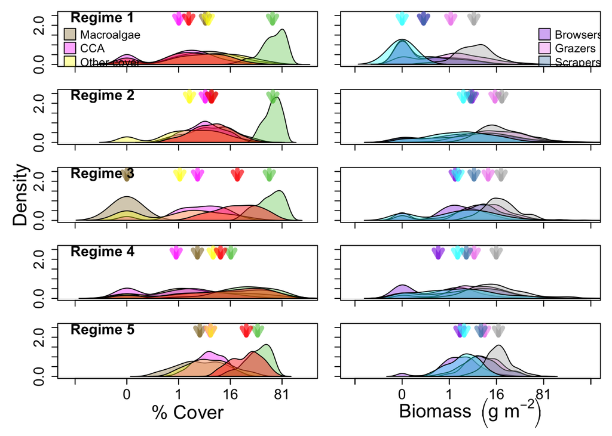

```r
# set up dataframe of results to plot
reg.split <- data[c('regime','Browsers','Grazers','Scrapers','SecConsumers','Predators','Macro','CCA','Other','Turf','Coral')]
rsum <- melt(reg.split, id=1)
rsum$value <- sqrt(sqrt(rsum$value))
rsum <- ddply(rsum, .(regime,variable), summarise, "mean"=mean(value))
rsum <- split(rsum, rsum$regime)
reg.split <- split(reg.split, reg.split$regime)

# set up colors for plot
shade <- 90
col.den2 <- c(
  rgb(138,43,226,shade,max=255), #Browser: blueviolet
  rgb(238,130,238,shade,max=255), #Grazer: violet
  rgb(70,130,180,shade,max=255),  #Scraper: steelblue
  rgb(169,169,169,shade,max=255), #SecCons: darkgrey
  rgb(0,255,255,shade,max=255), #Preadtor: cyan
  rgb(142,111,38,shade,max=255), #Macro: slate
  rgb(255,0,255,shade,max=255), #CCA: magenta
  rgb(255,255,0,shade,max=255),  #Other: light yellow
  rgb(92,198,72,shade,max=255), #Turf: green
  rgb(255,0,0,110,max=255) #Coral: orange-red
)

# plot
pl <- c("Regime 1", "Regime 2", "Regime 3", "Regime 4", "Regime 5")
par(mfcol=c(5,2), mar=c(1,1,1,1),oma=c(4,4,0,0))
d <- density(reg.split[[1]]$Turf)
plot(d,ylim=c(0,2.6),xlim=c(-1.15,3.5),main="",type="n",cex.axis=1.5,xaxt="n"); axis(1,labels=NA)
for(k in 7:11){
  x <- sqrt(sqrt(reg.split[[1]][,k]))
  p <- density(x)
  c <- k-1
  polygon(p,col=col.den2[c])
  arrows(rsum[[1]][c,3],2.6,rsum[[1]][c,3],2.1,lwd=5,length=.1,col=col.den2[c])
  arrows(rsum[[1]][c,3],2.6,rsum[[1]][c,3],2.1,lwd=5,length=.1,col=col.den2[c])
}
text(-1.2,2.35,pl[1],pos=4,cex=1.5,font=2)
legend(-1.3,2.25,legend=c("Macroalgae","CCA","Other cover","Turf","Coral"),pch=22,col="black",pt.bg=col.den2[6:10],pt.cex=3,bty="n",cex=1.2)

for(i in 2:5){
  d <- density(reg.split[[i]]$Turf)
  plot(d,ylim=c(0,2.6),xlim=c(-1.15,3.5),main="",type="n",cex.axis=1.5,xaxt="n"); axis(1,labels=NA)
  for(k in 7:11){
    x <- sqrt(sqrt(reg.split[[i]][,k]))
    p <- density(x)
    c <- k-1
    polygon(p,col=col.den2[c])
    arrows(rsum[[i]][c,3],2.6,rsum[[i]][c,3],2.1,lwd=5,length=.1,col=col.den2[c])
    arrows(rsum[[i]][c,3],2.6,rsum[[i]][c,3],2.1,lwd=5,length=.1,col=col.den2[c])
  }
  text(-1.2,2.35,pl[i],pos=4,cex=1.5,font=2)
}
axis(1,cex.axis=1.5,at=c(-1,0,1,2,3),labels=c("",0,1,16,81))
mtext("% Cover",side=1,outer=T,cex=1.3,at=0.25,line=1.7)

#fish
d <- density(reg.split[[1]]$Turf)
plot(d,ylim=c(0,2.6),xlim=c(-1.1,4),main="",type="n",cex.axis=1.5,xaxt="n",yaxt="n"); axis(1,labels=NA); axis(2,labels=NA)
for(k in 2:6){
  x <- sqrt(sqrt(reg.split[[1]][,k]))
  p <- density(x)
  c <- k-1
  polygon(p,col=col.den2[c])
  arrows(rsum[[1]][c,3],2.6,rsum[[1]][c,3],2.1,lwd=5,length=.1,col=col.den2[c])
  arrows(rsum[[1]][c,3],2.6,rsum[[1]][c,3],2.1,lwd=5,length=.1,col=col.den2[c])
}
legend(2.8,2.25,legend=c("Browsers","Grazers","Scrapers","Sec. Cons.","Piscivores"),pch=22,col="black",pt.bg=col.den2[1:5],pt.cex=3,bty="n",cex=1.2)

for(i in 2:5){
  d <- density(reg.split[[i]]$Turf)
  plot(d,ylim=c(0,2.6),xlim=c(-1.1,4),main="",type="n",cex.axis=1.5,xaxt="n",yaxt="n"); axis(1,labels=NA); axis(2,labels=NA)
  for(k in 2:6){
    x <- sqrt(sqrt(reg.split[[i]][,k]))
    p <- density(x)
    c <- k-1
    polygon(p,col=col.den2[c])
    arrows(rsum[[i]][c,3],2.6,rsum[[i]][c,3],2.1,lwd=5,length=.1,col=col.den2[c])
    arrows(rsum[[i]][c,3],2.6,rsum[[i]][c,3],2.1,lwd=5,length=.1,col=col.den2[c])
  }
  #   text(-1.2,2.35,pl[i],pos=4,cex=1.5,font=2)
}
axis(1,cex.axis=1.5,at=c(-1,0,1,2,3,4),labels=c("",0,1,16,81,""))

mtext(expression("Biomass"~~bgroup("(",'g '*m^{-2},")")),side=1,outer=T,cex=1.3,at=0.75,line=2.5)
mtext("Density",side=2,outer=T,cex=1.3,line=1.5)
```

## Temporal transition frequency

Predict regime for each observation

```r
# bind timeseries to bottom of data used to create regimes
temp <- data_time[c("Coral","Macro","Other","Turf","CCA","Browsers","Grazers","Scrapers","Predators","SecConsumers")]
temp <- rbind(data[c("Coral","Macro","Other","Turf","CCA","Browsers","Grazers","Scrapers","Predators","SecConsumers")],temp)
temp <- as.data.frame(lapply(temp, myscale))
temp <- sqrt(sqrt(temp))

# use predict function from mclust
time.pred <- predict(regmod_final, newdata=temp[1028:nrow(temp),])
```

Retain predictions with greater than 95% confidence

```r
tl <- as.data.frame(time.pred)
tl$z.1[tl$z.1 < 0.95] <- 0
tl$z.1[tl$z.1 >= 0.95] <- 1
tl$z.2[tl$z.2 < 0.95] <- 0
tl$z.2[tl$z.2 >= 0.95] <- 2
tl$z.3[tl$z.3 < 0.95] <- 0
tl$z.3[tl$z.3 >= 0.95] <- 3
tl$z.4[tl$z.4 < 0.95] <- 0
tl$z.4[tl$z.4 >= 0.95] <- 4
tl$z.5[tl$z.5 < 0.95] <- 0
tl$z.5[tl$z.5 >= 0.95] <- 5
tl$sm <- rowSums(tl[2:6])
tl$c <- ifelse(tl$classification==tl$sm,1,0)
```

Calucalate transition frequency

```r
tld <- cbind(data_time, clust=tl$classification, c=tl$c)
tld <- subset(tld, c==1) # removes predictions < 95%

# remove sites that don't have at least 3 years after the confidence threshold applied
temp <- ddply(tld, .(repID_ts), summarise, 'nYr'=length(unique(Year)))
temp <- subset(temp, nYr > 2)
tld <- tld[tld$repID_ts %in% temp$repID_ts,]
clustgrp <- data.frame("clust"=c(1,2,3,4,5),"regime"=c(3,1,2,5,4)) #renumber the regimes
tld <- join(tld,clustgrp,by='clust')

# create a dataframe where gap years are removed
tlw <- dcast(tld, repID_ts~Year,value.var="regime")
tm <- melt(tlw, id=c(1))
tm <- tm[c('repID_ts','variable','value')]
tm <- tm[!is.na(tm$value),]
tm$repID_ts <- as.factor(tm$repID_ts)
ot <- data.frame(repID_ts=NA,variable=NA,value=NA,s=NA)
for(i in 1:length(levels(tm$repID_ts))){
  temp <- tm[tm$repID_ts==levels(tm$repID_ts)[i],]
  temp$s <- seq(1:nrow(temp))
  ot <- rbind(ot,temp)
}
tmd <- dcast(ot, repID_ts~s, value.var='value')
tmd <- tmd[!is.na(tmd$repID_ts),]

# break down dataframe to include row for every transition
t.each <- data.frame(repID_ts=NA,Rs=NA,Re=NA)
for(i in 1:nrow(tmd)) t.each <- rbind(t.each,c(tmd$repID_ts[i],tmd$`1`[i],tmd$`2`[i]))
for(i in 1:nrow(tmd)) t.each <- rbind(t.each,c(tmd$repID_ts[i],tmd$`2`[i],tmd$`3`[i]))
for(i in 1:nrow(tmd)) t.each <- rbind(t.each,c(tmd$repID_ts[i],tmd$`3`[i],tmd$`4`[i]))
for(i in 1:nrow(tmd)) t.each <- rbind(t.each,c(tmd$repID_ts[i],tmd$`4`[i],tmd$`5`[i]))
for(i in 1:nrow(tmd)) t.each <- rbind(t.each,c(tmd$repID_ts[i],tmd$`5`[i],tmd$`6`[i]))
for(i in 1:nrow(tmd)) t.each <- rbind(t.each,c(tmd$repID_ts[i],tmd$`6`[i],tmd$`7`[i]))
for(i in 1:nrow(tmd)) t.each <- rbind(t.each,c(tmd$repID_ts[i],tmd$`7`[i],tmd$`8`[i]))
for(i in 1:nrow(tmd)) t.each <- rbind(t.each,c(tmd$repID_ts[i],tmd$`8`[i],tmd$`9`[i]))
for(i in 1:nrow(tmd)) t.each <- rbind(t.each,c(tmd$repID_ts[i],tmd$`9`[i],tmd$`10`[i]))
t.each <- t.each[!is.na(t.each$repID_ts),]
t.each <- t.each[!is.na(t.each$Rs),]
t.each <- t.each[!is.na(t.each$Re),]

# create empty dataframe to store results that includes each transition possibilty
trans <- data.frame(Rs=c(1,2,3,4,5,1,1,1,1,2,2,2,2,3,3,3,3,4,4,4,4,5,5,5,5),Re=c(1,2,3,4,5,2,3,4,5,1,3,4,5,1,2,4,5,1,2,3,5,1,2,3,4),nT=rep(NA,25))

# fill in counts for each transition possiblity
for(r in 1:5){
  for(e in 1:5){
    tramp <- rep(F,nrow(t.each))
    tramp[t.each[,'Rs']==r & t.each[,'Re']==e] <- T
    trans$nT[trans$Rs==r & trans$Re==e] <- length(tramp[tramp==T])
  }
}
sum(trans$nT) # total number of observed transitions
```

```
## [1] 261
```

```r
trans$prop <- trans$nT/sum(trans$nT) # convert to proportion
round(dcast(trans, Rs~Re, value.var='prop'),2) # transition matrix
```

```
##   Rs    1    2    3    4    5
## 1  1 0.09 0.03 0.00 0.01 0.01
## 2  2 0.00 0.43 0.00 0.03 0.00
## 3  3 0.00 0.00 0.00 0.01 0.00
## 4  4 0.03 0.03 0.01 0.11 0.04
## 5  5 0.00 0.01 0.00 0.01 0.12
```

Plot heatmap

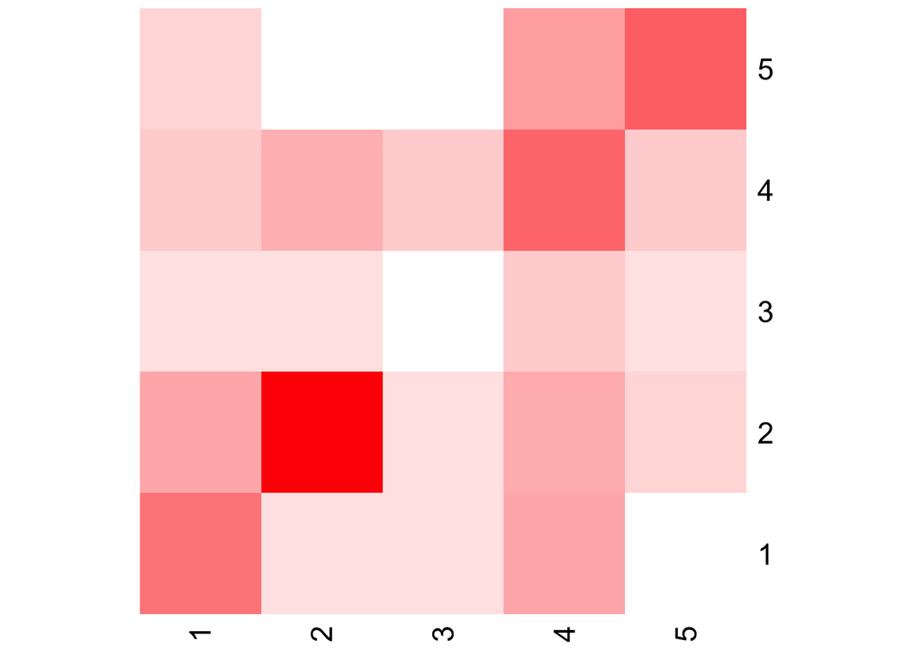

```r
temp <- dcast(trans, Rs~Re, value.var='nT')
temp <- temp[,2:6]
ctm <- colorRampPalette(c("white","red"))

heatmap(as.matrix(t(sqrt(temp))),Rowv=NA,Colv=NA,scale="none",col=ctm(200),margins=c(2,2))
```

*Note this plot is flipped to the right in the paper and the rest of the figure was constructed external to R.*

## Sensitivity to number of years

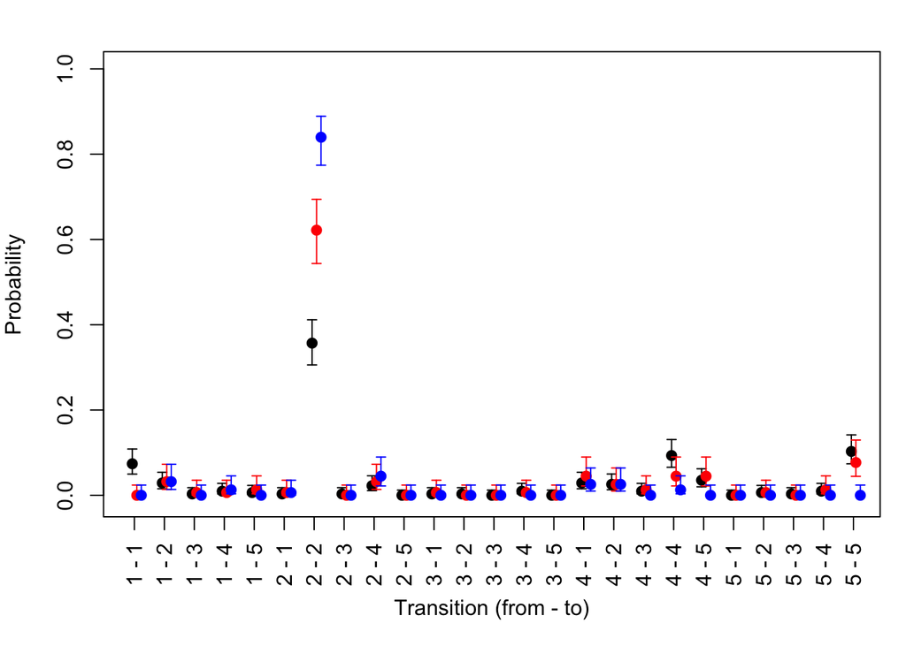

```r
# create dataframe with counts for number of years at each site
ts.long <- ddply(data_time, .(repID_ts),summarise, "nYr"=length(unique(Year)), "min"=min(Year), "max"=max(Year))

# binomial confidence intervals for main result
tmf.all.conf <- binconf(trans$nT,n=311,alpha=0.05)

# redo result with timeseries greater than 4 years long
trans.long <- data.frame(Rs=c(1,2,3,4,5,1,1,1,1,2,2,2,2,3,3,3,3,4,4,4,4,5,5,5,5),Re=c(1,2,3,4,5,2,3,4,5,1,3,4,5,1,2,4,5,1,2,3,5,1,2,3,4),nT=rep(NA,25))
t.each.long <- subset(ts.long, nYr > 4)
t.each.long <- t.each[t.each$repID_ts %in% t.each.long$repID_ts,]
for(r in 1:5){
  for(e in 1:5){
    tramp <- rep(F,nrow(t.each.long))
    tramp[t.each.long[,'Rs']==r & t.each.long[,'Re']==e] <- T
    trans.long$nT[trans.long$Rs==r & trans.long$Re==e] <- length(tramp[tramp==T])
  }
}
tmf.long.conf <- binconf(trans.long$nT,n=sum(trans.long$nT),alpha=0.05)

# redo result with timeseries greater than 6 years long
trans.longer <- data.frame(Rs=c(1,2,3,4,5,1,1,1,1,2,2,2,2,3,3,3,3,4,4,4,4,5,5,5,5),Re=c(1,2,3,4,5,2,3,4,5,1,3,4,5,1,2,4,5,1,2,3,5,1,2,3,4),nT=rep(NA,25))
t.each.longer <- subset(ts.long, nYr > 6)
t.each.longer <- t.each[t.each$repID_ts %in% t.each.longer$repID_ts,]
for(r in 1:5){
  for(e in 1:5){
    tramp <- rep(F,nrow(t.each.long))
    tramp[t.each.longer[,'Rs']==r & t.each.longer[,'Re']==e] <- T
    trans.longer$nT[trans.longer$Rs==r & trans.longer$Re==e] <- length(tramp[tramp==T])
  }
}
tmf.longer.conf <- binconf(trans.longer$nT,n=sum(trans.longer$nT),alpha=0.05)

# combine together for plot
tmf.confs <- cbind(tmf.all.conf,tmf.long.conf,tmf.longer.conf)
tmf.confs <- as.data.frame(tmf.confs)
colnames(tmf.confs) <- c("pt.all","low.all","up.all","pt.long","low.long","up.long","pt.longer","low.longer","up.longer")
rownames(tmf.confs) <- seq(1:25)

#plot labels
tmf.lab <- data.frame(Rs=c(1,2,3,4,5,1,1,1,1,2,2,2,2,3,3,3,3,4,4,4,4,5,5,5,5),Re=c(1,2,3,4,5,2,3,4,5,1,3,4,5,1,2,4,5,1,2,3,5,1,2,3,4)); tmf.lab$lab <- paste(tmf.lab$Rs,tmf.lab$Re,sep=" - ")
tmf.confs <- tmf.confs[c(1, 6, 7, 8, 9, 10, 2, 11, 12, 13, 14, 15, 3, 16, 17, 18, 19, 20, 4, 21, 22, 23, 24, 25, 5),]
tmf.lab <- tmf.lab[c(1, 6, 7, 8, 9, 10, 2, 11, 12, 13, 14, 15, 3, 16, 17, 18, 19, 20, 4, 21, 22, 23, 24, 25, 5),]

#plot
par(mar=c(5,4,2,1))
plot(seq(1:25), tmf.confs$pt.all,pch=19,ylim=c(-0.01,1),xaxt="n",ylab="Probability",xlab="Transition (from - to)")
axis(1, at= seq(1:25)+0.07, labels= tmf.lab$lab,las=2)
plotCI(seq(1:25), tmf.confs$pt.all, ui=tmf.confs$up.all,li=tmf.confs$low.all,add=T,pch=NA,sfrac=0.005)
points(seq(1:25)+0.15, tmf.confs$pt.long,pch=19,col="red")
plotCI(seq(1:25)+0.15, tmf.confs$pt.long, ui=tmf.confs$up.long,li=tmf.confs$low.long,add=T,pch=NA,col="red",sfrac=0.005)
points(seq(1:25)+0.30, tmf.confs$pt.longer,pch=19,col="blue")
plotCI(seq(1:25)+0.30, tmf.confs$pt.longer, ui=tmf.confs$up.longer,li=tmf.confs$low.longer,add=T,pch=NA,col="blue",sfrac=0.005)
```

Summaries in the text

```r
temp <- subset(trans, Rs == 1)
temp$prop1 <- temp$nT/sum(temp$nT)
temp
```

```
##   Rs Re nT        prop      prop1
## 1  1  1 23 0.088122605 0.60526316
## 6  1  2  9 0.034482759 0.23684211
## 7  1  3  1 0.003831418 0.02631579
## 8  1  4  3 0.011494253 0.07894737
## 9  1  5  2 0.007662835 0.05263158
```

```r
temp <- subset(trans, Rs == 2)
temp$prop2 <- temp$nT/sum(temp$nT)
temp
```

```
##    Rs Re  nT        prop       prop2
## 2   2  2 111 0.425287356 0.925000000
## 10  2  1   1 0.003831418 0.008333333
## 11  2  3   1 0.003831418 0.008333333
## 12  2  4   7 0.026819923 0.058333333
## 13  2  5   0 0.000000000 0.000000000
```

```r
temp <- subset(trans, Rs == 4)
temp$prop4 <- temp$nT/sum(temp$nT)
temp
```

```
##    Rs Re nT       prop     prop4
## 4   4  4 29 0.11111111 0.4833333
## 18  4  1  9 0.03448276 0.1500000
## 19  4  2  8 0.03065134 0.1333333
## 20  4  3  3 0.01149425 0.0500000
## 21  4  5 11 0.04214559 0.1833333
```

```r
temp <- subset(trans, Rs == 5)
temp$prop5 <- temp$nT/sum(temp$nT)
temp
```

```
##    Rs Re nT        prop      prop5
## 5   5  5 32 0.122605364 0.84210526
## 22  5  1  0 0.000000000 0.00000000
## 23  5  2  2 0.007662835 0.05263158
## 24  5  3  1 0.003831418 0.02631579
## 25  5  4  3 0.011494253 0.07894737
```

## Local and global impacts

First step was to calculate new transition matrix that lowers the confidence threshold to maximize samples from after the bleaching event

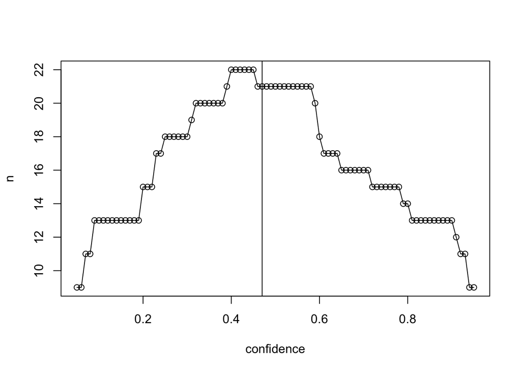

```r
temp <- data.frame(tp=seq(0.05,0.95,by=0.01),n=rep(NA,length(seq(0.05,0.95,by=0.01))))
for(z in 1:nrow(temp)){
  tp <- temp$tp[z]
  tl2 <- as.data.frame(time.pred)
  tl2$z.1[tl2$z.1 < tp] <- 0
  tl2$z.1[tl2$z.1 >= tp] <- 1
  tl2$z.2[tl2$z.2 < tp] <- 0
  tl2$z.2[tl2$z.2 >= tp] <- 2
  tl2$z.3[tl2$z.3 < tp] <- 0
  tl2$z.3[tl2$z.3 >= tp] <- 3
  tl2$z.4[tl2$z.4 < tp] <- 0
  tl2$z.4[tl2$z.4 >= tp] <- 4
  tl2$z.5[tl2$z.5 < tp] <- 0
  tl2$z.5[tl2$z.5 >= tp] <- 5
  tl2$sm <- rowSums(tl2[2:6])
  tl2$c <- ifelse(tl2$classification==tl2$sm,1,0)

  tld2 <- cbind(data_time, clust=tl2$classification, c=tl2$c)
  tld2 <- subset(tld2, c==1)
  tld2 <- join(tld2,clustgrp,by="clust")
  # head(tld2)

  tlw2 <- dcast(tld2, repID_ts~Year,value.var="regime")
  # head(tlw2)
  for(i in 2:19){colnames(tlw2)[i] <- paste0('y',i)}

  temp[z,2] <- nrow(tlw2[!is.na(tlw2$y19),])

}

plot(temp$tp,temp$n,type="o",ylab='n',xlab='confidence')
abline(v=0.47)
```

This plot shows how many samples will be available for the model across varying levels of confidence.

```r
tp <- 0.46 #based on above plot
tl2 <- as.data.frame(time.pred)
tl2$z.1[tl2$z.1 < tp] <- 0
tl2$z.1[tl2$z.1 >= tp] <- 1
tl2$z.2[tl2$z.2 < tp] <- 0
tl2$z.2[tl2$z.2 >= tp] <- 2
tl2$z.3[tl2$z.3 < tp] <- 0
tl2$z.3[tl2$z.3 >= tp] <- 3
tl2$z.4[tl2$z.4 < tp] <- 0
tl2$z.4[tl2$z.4 >= tp] <- 4
tl2$z.5[tl2$z.5 < tp] <- 0
tl2$z.5[tl2$z.5 >= tp] <- 5
tl2$sm <- rowSums(tl2[2:6])
tl2$c <- ifelse(tl2$classification==tl2$sm,1,0)

tld2 <- cbind(data_time, clust=tl2$classification, c=tl2$c)
tld2 <- subset(tld2, c==1)
tld2 <- join(tld2,clustgrp,by="clust")

tlw2 <- dcast(tld2, repID_ts~Year,value.var="regime")
for(i in 2:19){colnames(tlw2)[i] <- paste0('y',i)}

temp <- temp <- join(tlw2,drivers,by='repID_ts')
temp <- temp[!is.na(temp$y19),]
dat.dhw <- temp
```

Bayesian logistic regression Model

```r
# set up and define Bayesian logisitic regression
cat('model{
    # likelihood
    for(i in 1:n){
      p[i] <- ilogit(B0 + B1*x[i])
      p.bound[i] <- max(0, min(1,p[i]))
      y[i] ~ dbern(p.bound[i])
      y.new[i] ~ dbern(p[i])
    }

    # priors
    B0 ~ dnorm(0,0.001)
    B1 ~ dnorm(0,0.001)

    # predicted values
    for(i in 1:length(x.new)){
      y.pred[i] <- ilogit(B0 + B1*x.new[i])
    }

    #posterior predictive checks
    y.mean <- mean(y)
    ynew.mean <- mean(y.new)
    pval.mean <- step(y.mean-ynew.mean)

    sd.y <- sd(y)
    sd.y.new <- sd(y.new)
    pval.sd <- step(sd.y.new-sd.y)

    }',file='LogisitcJags_wPPC.R')
```

Set up model inputs and outputs

```r
options <- data.frame(Rs=c(1,1,1,1,1,2,2,2,2,2,3,3,3,3,3,4,4,4,4,4,5,5,5,5,5),
                      Re=c(1,2,3,4,5,1,2,3,4,5,1,2,3,4,5,1,2,3,4,5,1,2,3,4,5))

gel.out.hpop <- data.frame('B0'=rep(NA,nrow(options)),'B1'=rep(NA,nrow(options)))
ppc.out.hpop <- data.frame('mean'=rep(NA,nrow(options)),'sd'=rep(NA,nrow(options)))

gel.out.dhw <- data.frame('B0'=rep(NA,nrow(options)),'B1'=rep(NA,nrow(options)))
ppc.out.dhw <- data.frame('mean'=rep(NA,nrow(options)),'sd'=rep(NA,nrow(options)))

n.adapt <- 5000; n.update <- 10000; n.iter <- 10000
initFunc <- function(){return(list(list(B0=runif(1,0,1),B1=runif(1,0,1))))}

dat.hpop <- join(t.each,drivers,by='repID_ts')
dat.hpop$humanpop.l <- log(dat.hpop$humanpop+1)
cent <- function(x){(x-min(x))/(max(x)-min(x))}
dat.hpop$humanpop.l <- cent(dat.hpop$humanpop.l)
x.new.hpop <- seq(from=min(dat.hpop$humanpop.l),to=max(dat.hpop$humanpop.l),length=100)


gel.out.dhw <- data.frame('B0'=rep(NA,nrow(options)),'B1'=rep(NA,nrow(options)))
ppc.out.dhw <- data.frame('mean'=rep(NA,nrow(options)),'sd'=rep(NA,nrow(options)))

dat.dhw$dhw <- cent(dat.dhw$dhw)
x.new.dhew <- seq(from=min(dat.dhw$dhw),to=max(dat.dhw$dhw),length=100)


col.vec <- wes_palette(name="Darjeeling1",n=5)
col.vec <- c(rgb(col2rgb(col.vec[1])[1,1],col2rgb(col.vec[1])[2,1],col2rgb(col.vec[1])[3,1],100,max=255),rgb(col2rgb(col.vec[2])[1,1],col2rgb(col.vec[2])[2,1],col2rgb(col.vec[2])[3,1],100,max=255),rgb(col2rgb(col.vec[3])[1,1],col2rgb(col.vec[3])[2,1],col2rgb(col.vec[3])[3,1],100,max=255),rgb(238,130,238,100,max=255))
```

Fit models and plot together

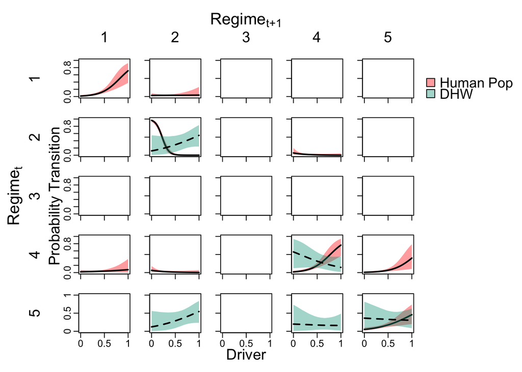

```r
# example for the first transition (see .rmd for full figure code)
for(k in 1:1){
  dat.hpop$tramp <- rep(0,nrow(dat.hpop)) # set up empty column
  dat.hpop$tramp[dat.hpop[,'Rs']==options[k,'Rs'] & dat.hpop[,'Re']==options[k,'Re']] <- 1 # store result for transition of interest
  # plot(dat.hpop$humanpop.l,dat.hpop$tramp,ylim=c(0,1),ylab="",xlab="",type="n",xaxt="n",cex.axis=1.2) # empty plot
  # axis(1,at=c(0,0.5,1),labels=c('','',''))
  if(nrow(dat.hpop[dat.hpop$tramp==1,])>3){ # run bayesian model if n > 3
    data <- list(n=nrow(dat.hpop),y=dat.hpop$tramp,x=dat.hpop$humanpop.l,x.new=x.new.hpop)
    cl <- makeCluster(2) # run chains in parallel for increased speed
    clusterExport(cl,c('data','initFunc','n.adapt','n.update','n.iter'))
    out <- clusterEvalQ(cl,{
      library(rjags)
      bmod <- jags.model('LogisitcJags_wPPC.R',data=data,inits=initFunc(),n.chains=1,n.adapt=n.adapt)
      update(bmod,n.iter=n.update)
      bmod.c <- coda.samples(bmod,variable.names=c('B0','B1','y.new','y.pred','pval.mean','pval.sd'),n.iter=n.iter,thin=1)
      return(as.mcmc(bmod.c))
    })
    bmod.c <- mcmc.list(out)
    stopCluster(cl)
    # save results of gelman diagnositics
    gel.out.hpop[k,'B0'] <- gelman.diag(bmod.c[,'B0'])$psrf[1]
    gel.out.hpop[k,'B1'] <- gelman.diag(bmod.c[,'B1'])$psrf[1]
    # save model summary results
    ppc.out.hpop[k,'mean'] <- summary(bmod.c)$statistics['pval.mean','Mean']
    ppc.out.hpop[k,'sd'] <- summary(bmod.c)$statistics['pval.sd','Mean']

    grepgo <- grep('y.pred',colnames(bmod.c[[1]])) # set up for plotting
    # plot results
    # polygon(c(x.new.hpop,rev(x.new.hpop)),c(summary(bmod.c)$quantiles[grepgo,'97.5%'],rev(summary(bmod.c)$quantiles[grepgo,'2.5%'])),col=col.vec[1],border=NA)
    # points(x.new.hpop,summary(bmod.c)$quantiles[grepgo,'50%'],pch=19,type="l",lwd=2)
  }
}
```